# Data Visualization using R

02-06/12/2019

## Day 1

## Plan for the day

### Morning

- Arsenio: Introduction and week plan
- Ben: What is R? Why use R?
- Joe: The learning curve and motivation
- Arsenio: **Preparing the environment**

### Afternoon

- Arsenio: **Preparing the data** (basic only, save databases, etc. for day 5)
- Ben: **Introduction to ggplot2** (context, rationale, structure)
- Joe: First chart

## Introduction and week plan (Arsenio)

- Main goals for the course
- Main goals for each day

## What is R? (Ben)

- Why use it?
  - Intuitive, powerful, and popular.
  - Open source: it’s free and maintained and upadated by programmers all over the world.

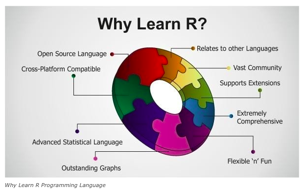

## What is R? (Ben)

- Object oriented programming language -Designed to make data handling and statitics intuitive.
- Why use it?
  - Intuitive, powerful, and popular.
  - Open source: it’s free and maintained and upadated by programmers all over the world.

## There is a package for that!

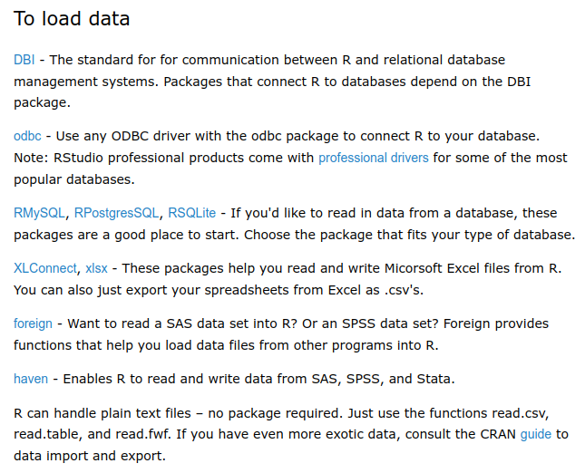

## There is a package for that!

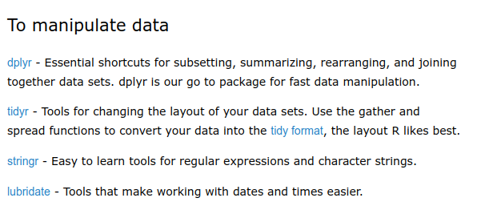

## There is a package for that!

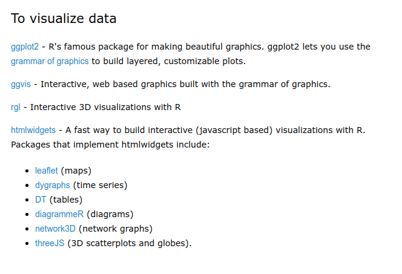

## There is a package for that!

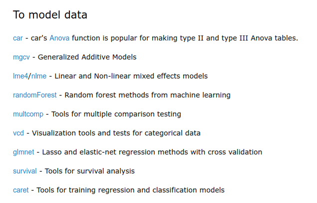

## There is a package for that!

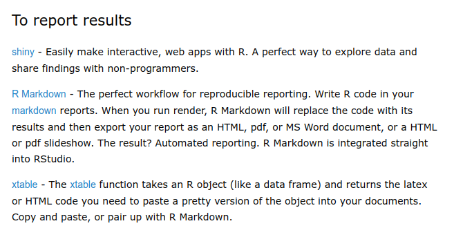

## There is a package for that!

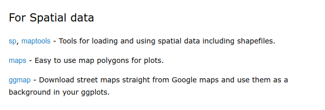

## There is a package for that!

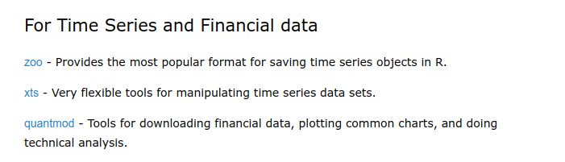

## There is a package for that!

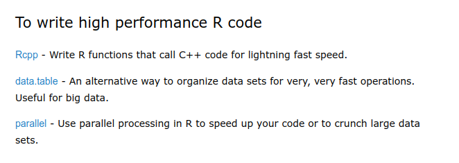

## There is a package for that!

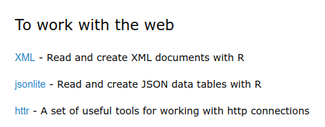

## There is a package for that!

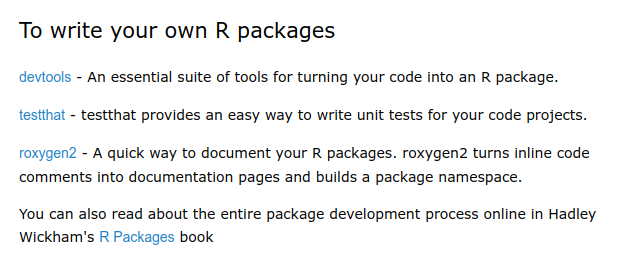

## R is fast

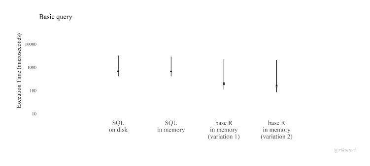

## R is beautiful

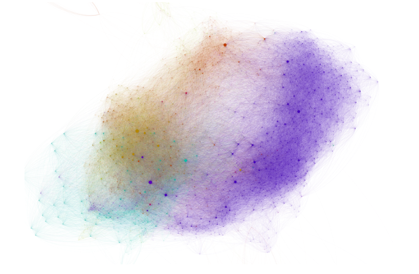

## R is beautiful

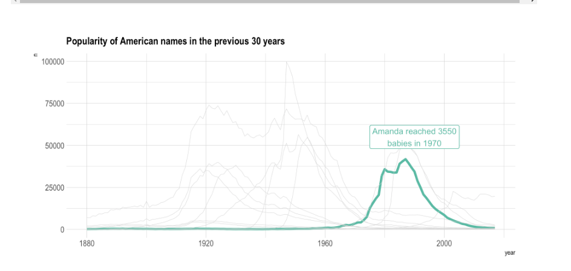

## R is beautiful

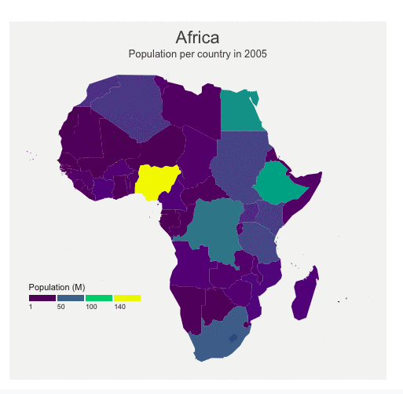

## R is beautiful

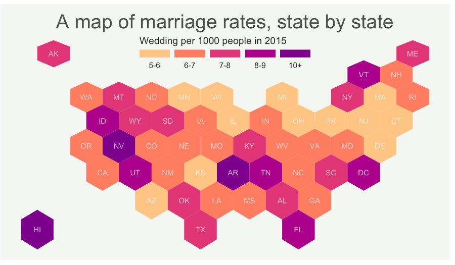

## R is beautiful

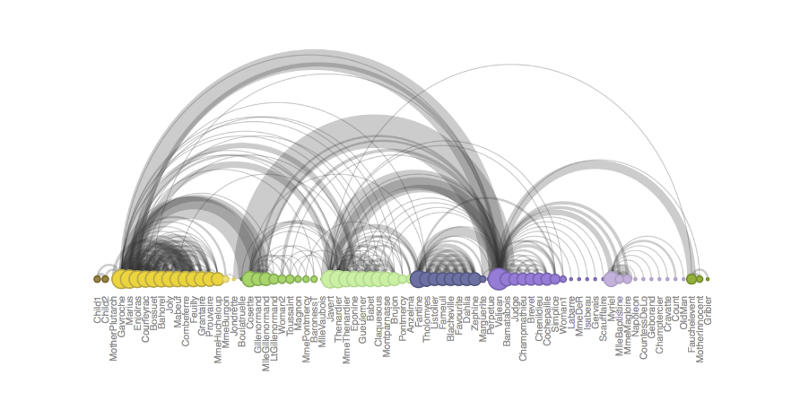

## The learning curve (Joe)

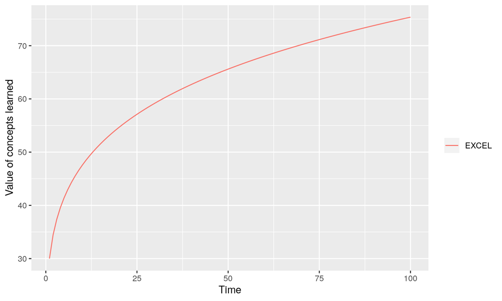

## The learning curve (Joe)

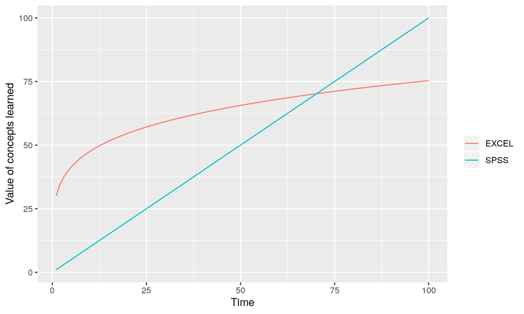

## The learning curve (Joe)

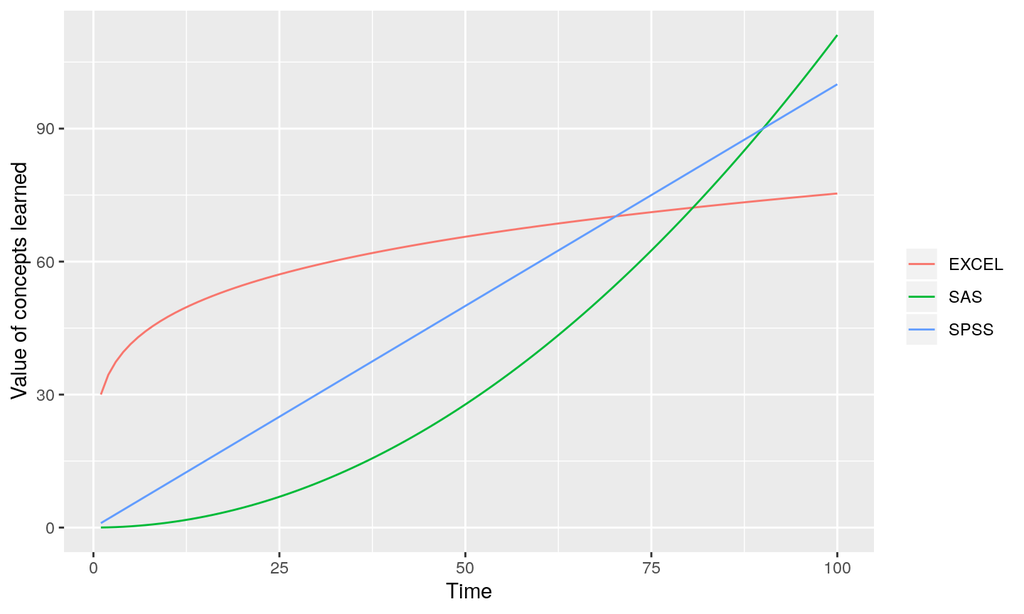

## The learning curve (Joe)

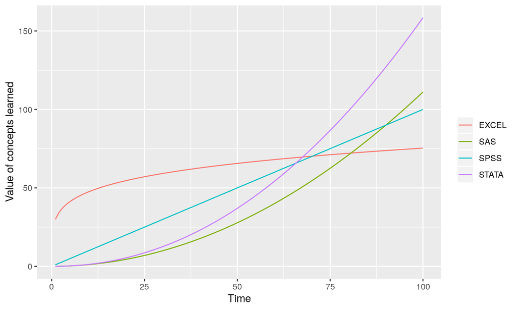

## The learning curve (Joe)

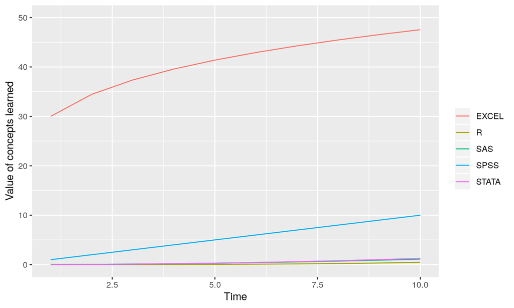

## The learning curve (Joe)

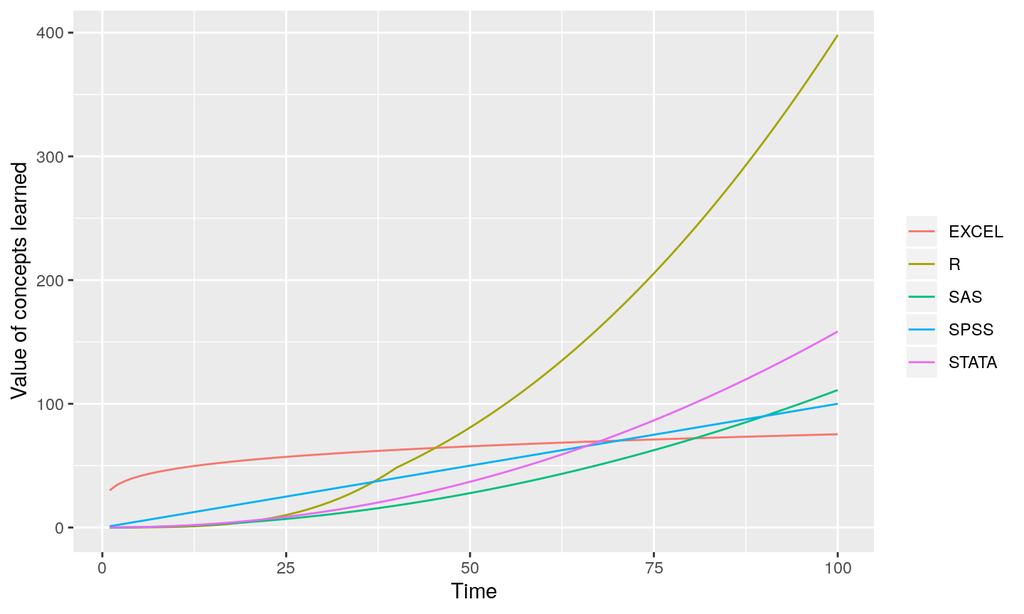

## Preparing the environment (Arsenio)

- Installing R
- Installing RStudio
- Understanding the interface / the 4 panels
  - The scripts.
  - The console.
  - The global environment.
  - The plots.

## Preparing the environment

### Installing R and RStudio

For this training, we will use:

1. **R** – a free software environment for statistical computing and graphics (download and install from https://cloud.r-project.org/)
2. **RStudio** – an integrated development environment for R (download and install from https://rstudio.com/products/rstudio/download/)
3. **Packages** – extend the capabilities of R. To install a package, open RStudio then
   - Packages –> Install –> *type the package name in Packages* –> Install or
   - Type `install.packages("package_name")` then hit Enter key
     - e.g.: install.packages(“plotly”)

## How to use/load a package (Arsenio)

Use a function without loading its package:

- `package_name::function_name()`

Load a package so that all ist function are readily avaible

- `library(package_name)`

## How to use/load a package (Arsenio)

Use a function after loading its package:

- `function_name()`

R loads automatically a set of packages necessary for its basic functionality

## Afternoon

## Afternoon

## Preparing the data (Arsenio)

- Exploring packages and functions to read in data.
- Preparing the data for analysis and visualization.

## Introduction to ggplot2 (Ben)

- The advantages of ggplot.
- Quick, simple, and beautiful.
- Exploring the basics as well as showing the potential.

## The advantages

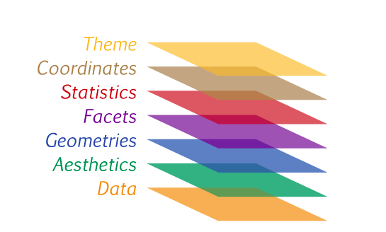

## The advantages

- Its part of a pipeline of well maintained packages.
- Tidyverse = readr -> dplyr -> ggplot2

## Quck and simple

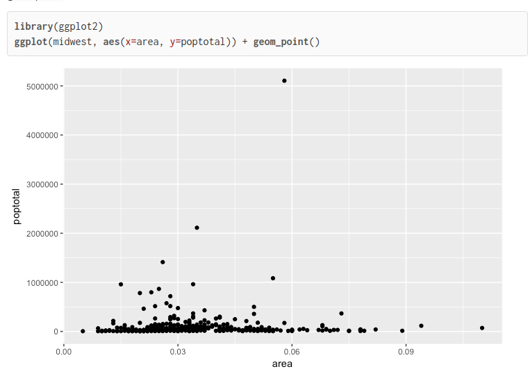

## Quck and simple

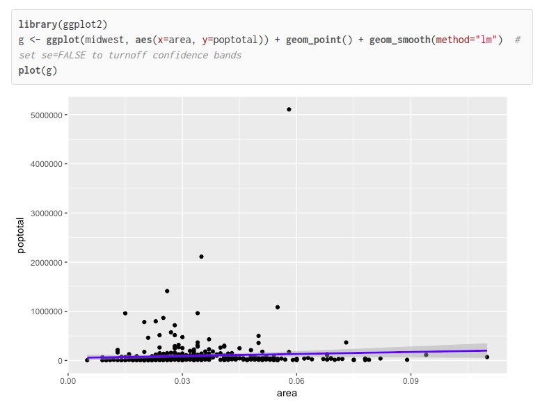

## Quck and simple

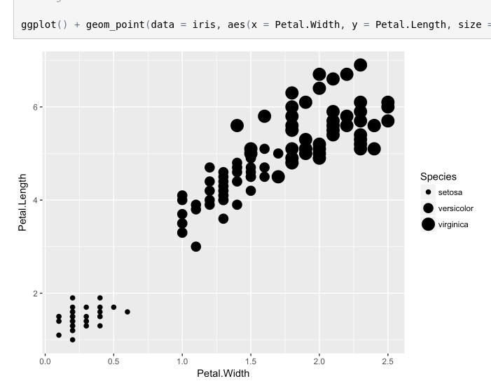

## the potential

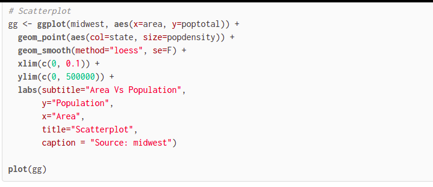

## the potential

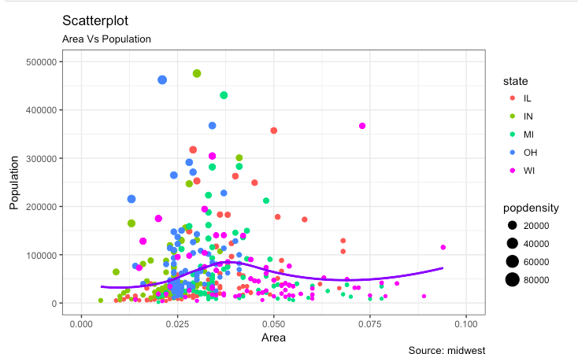

## the potential

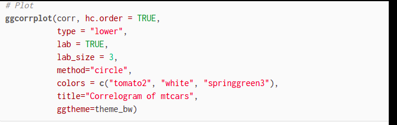

## the potential

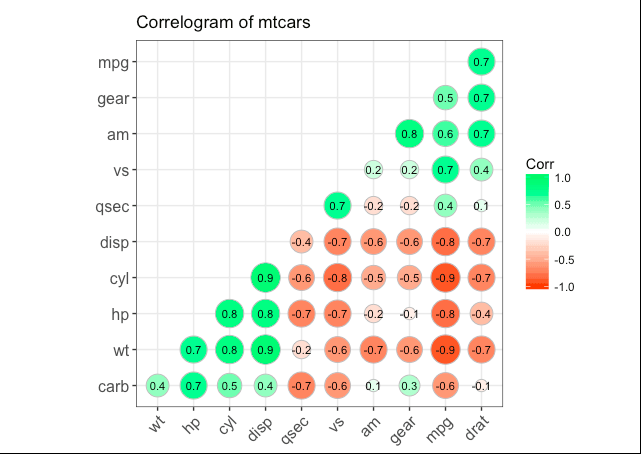